# Titanic : Machine Learning from disaster

### Introduction

The objective of this project was to complete the analysis of what sorts of people were likely to survive. In particular , the kaggle competition ask’s you to apply the tools of machine learning to predict which passengers survived the tragedy.

### First prediction

My first analysis was studing the structure of data and to find out how many passangers have survived and how many have passed away. The table command helped me explore if a variable has any predictive value. The variables that had influence on the survival rate were gender and age. Using these variables i made a simple prediction on the test dataset.

```r
# Structure of training and test set
str(train)
```

```
## 'data.frame':    891 obs. of  12 variables:
##  $ PassengerId: int  1 2 3 4 5 6 7 8 9 10 ...
##  $ Survived   : int  0 1 1 1 0 0 0 0 1 1 ...
##  $ Pclass     : int  3 1 3 1 3 3 1 3 3 2 ...
##  $ Name       : Factor w/ 891 levels "Abbing, Mr. Anthony",..: 109 191 358 277 16 559 520 629 416 581 ...
##  $ Sex        : Factor w/ 2 levels "female","male": 2 1 1 1 2 2 2 2 1 1 ...
##  $ Age        : num  22 38 26 35 35 NA 54 2 27 14 ...
##  $ SibSp      : int  1 1 0 1 0 0 0 3 0 1 ...
##  $ Parch      : int  0 0 0 0 0 0 0 1 2 0 ...
##  $ Ticket     : Factor w/ 681 levels "110152","110413",..: 525 596 662 50 473 276 86 396 345 133 ...
##  $ Fare       : num  7.25 71.28 7.92 53.1 8.05 ...
##  $ Cabin      : Factor w/ 148 levels "","A10","A14",..: 1 83 1 57 1 1 131 1 1 1 ...
##  $ Embarked   : Factor w/ 4 levels "","C","Q","S": 4 2 4 4 4 3 4 4 4 2 ...
```

```r
str(test)
```

```
## 'data.frame':    418 obs. of  11 variables:
##  $ PassengerId: int  892 893 894 895 896 897 898 899 900 901 ...
##  $ Pclass     : int  3 3 2 3 3 3 3 2 3 3 ...
##  $ Name       : Factor w/ 418 levels "Abbott, Master. Eugene Joseph",..: 210 409 273 414 182 370 85 58 5 104 ...
##  $ Sex        : Factor w/ 2 levels "female","male": 2 1 2 2 1 2 1 2 1 2 ...
##  $ Age        : num  34.5 47 62 27 22 14 30 26 18 21 ...
##  $ SibSp      : int  0 1 0 0 1 0 0 1 0 2 ...
##  $ Parch      : int  0 0 0 0 1 0 0 1 0 0 ...
##  $ Ticket     : Factor w/ 363 levels "110469","110489",..: 153 222 74 148 139 262 159 85 101 268 ...
##  $ Fare       : num  7.83 7 9.69 8.66 12.29 ...
##  $ Cabin      : Factor w/ 77 levels "","A11","A18",..: 1 1 1 1 1 1 1 1 1 1 ...
##  $ Embarked   : Factor w/ 3 levels "C","Q","S": 2 3 2 3 3 3 2 3 1 3 ...
```

```r
# Passengers that survived vs passengers that passed away

table(train$Survived)
```

```
##
##   0   1
## 549 342
```

```r
prop.table(table(train$Survived))
```

```
##
##         0         1
## 0.6161616 0.3838384
```

```r
# Males & females that survived vs males & females that passed away
table(train$Sex, train$Survived)
```

```
##
##            0   1
##   female  81 233
##   male   468 109
```

```r
prop.table(table(train$Sex, train$Survived), 1)
```

```
##
##                  0         1
##   female 0.2579618 0.7420382
##   male   0.8110919 0.1889081
```

```r
# Create the column child, and indicate whether child or no child
train$Child <- NA
train$Child[train$Age < 18] <- 1
train$Child[train$Age >= 18] <- 0

# Two-way comparison
table(train$Child, train$Survived)
```

```
##
##       0   1
##   0 372 229
##   1  52  61
```

```r
prop.table(table(train$Child, train$Survived), 1)
```

```
##
##             0         1
##   0 0.6189684 0.3810316
##   1 0.4601770 0.5398230
```

```r
# Prediction based on gender
test_one <- test
test_one$Survived <- NA
test_one$Survived[test_one$Sex == 'female'] <- 1
test_one$Survived[test_one$Sex == 'male'] <- 0
```

### Prediction using Decision tree

Created a decision tree using rpart function and discovered variables that play an important role whether or not a passenger will survive. Made prediction using the test set and got a result that outperforms a solution using purely gender. To improve the model, manipulated the cp and minisplit in the decision tree.

cp - determines when the splitting up of the decision tree stops.

minsplit - determines the minimum amount of observations in a leaf of the tree.

The model genarlizes well compared to previous one.

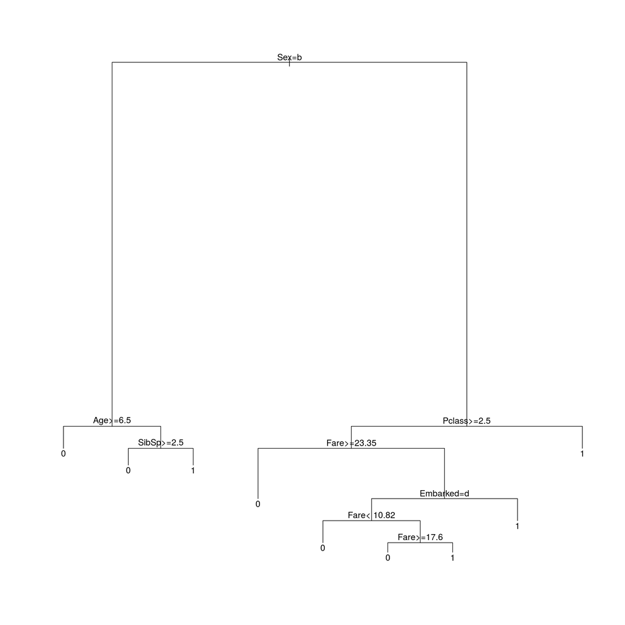

```r
# Build the decision tree
my_tree_two <- rpart(Survived ~ Pclass + Sex + Age + SibSp + Parch + Fare + Embarked,
                      data = train, method = "class")

# Visualize the decision tree
plot(my_tree_two)
text(my_tree_two)
```

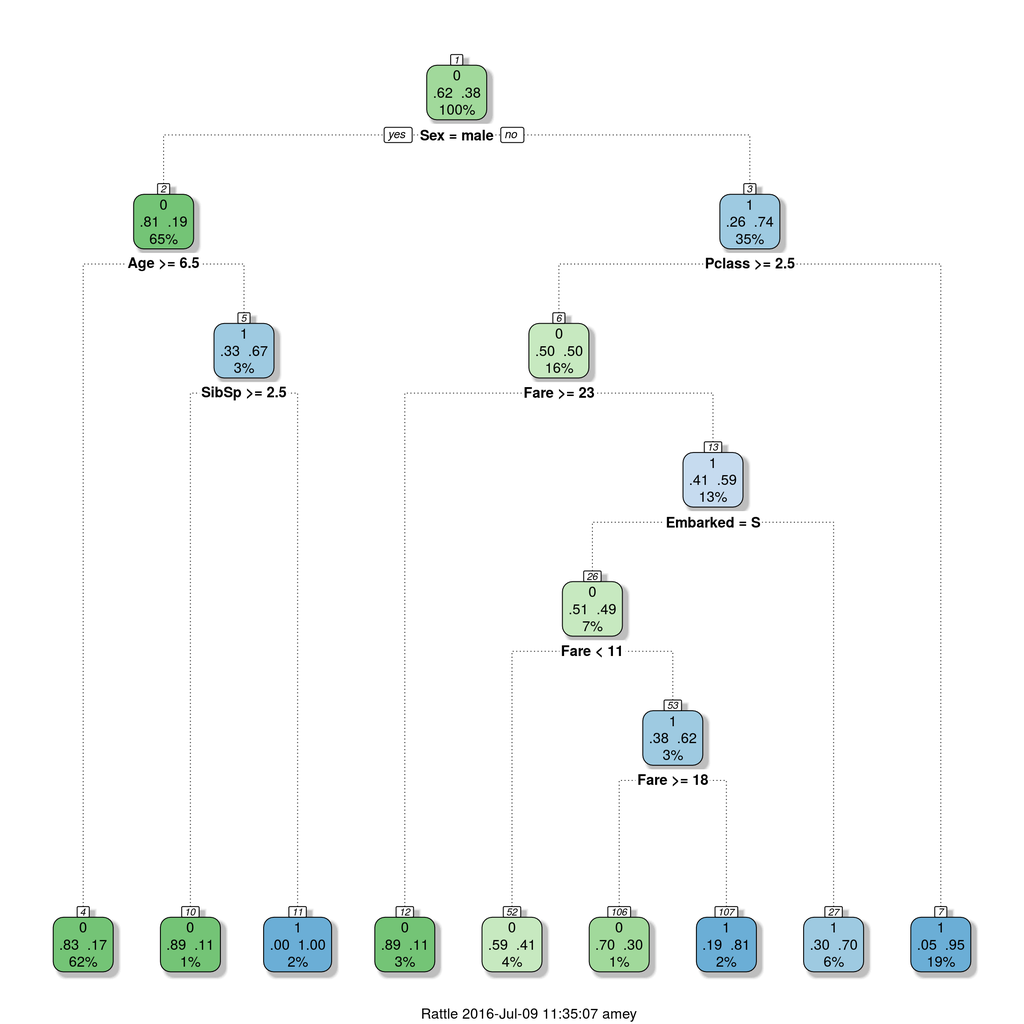

```r
# Plot the tree
fancyRpartPlot(my_tree_two)
```

```r
# Make prediction using the test set
my_prediction <- predict(my_tree_two, test, type="class")

# Create a data frame with two columns: PassengerId & Survived. Survived contains predictions
my_solution <- data.frame(PassengerId = test$PassengerId , Survived = my_prediction)

# Check that data frame has 418 entries
nrow(my_solution) == 418
```

```
## [1] TRUE
```

```r
# Write solution to a csv file with the name my_solution.csv
write.csv(my_solution,  file = 'my_solution.csv', row.names = FALSE)

# Create a new decision tree
my_tree_three <-   rpart(Survived ~ Pclass + Sex + Age + SibSp + Parch + Fare + Embarked,
                          data = train, method = "class", control = rpart.control(minsplit = 50, cp = 0))
                          rpart.control(cp = 0, minsplit = 50)
```

```
## $minsplit
## [1] 50
##
## $minbucket
## [1] 17
##
## $cp
## [1] 0
##
## $maxcompete
## [1] 4
##
## $maxsurrogate
## [1] 5
##
## $usesurrogate
## [1] 2
##
## $surrogatestyle
## [1] 0
##
## $maxdepth
## [1] 30
##
## $xval
## [1] 10
```

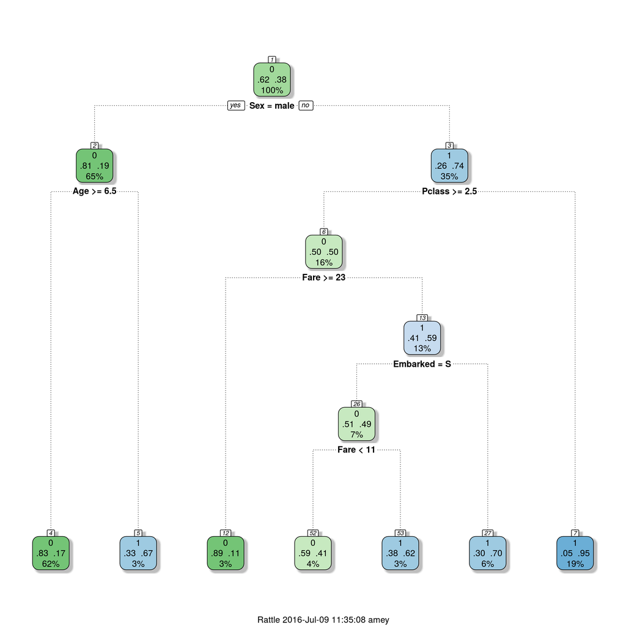

```r
# Visualize new decision tree
fancyRpartPlot(my_tree_three)
```

```r
# View my_solution
my_solution
```

```
##     PassengerId Survived
## 1           892        0
## 2           893        0
## 3           894        0
## 4           895        0
## 5           896        1
## 6           897        0
## 7           898        1
## 8           899        0
## 9           900        1
## 10          901        0
## 11          902        0
## 12          903        0
## 13          904        1
## 14          905        0
```

[output cut: 404 more lines]

### Improve prediction

To improve prediction, a valid assumption is that larger families need more time to get together on a sinking ship, and hence have less chance of surviving. Family size is determined by the variables SibSp and Parch, which indicate the number of family members a certain passenger is traveling with. So we need to add a new variable family_size, which is the sum of SibSp and Parch plus one (the observation itself), to the test and train set. In model five another important variable ‘Title’ is added to the decision tree.

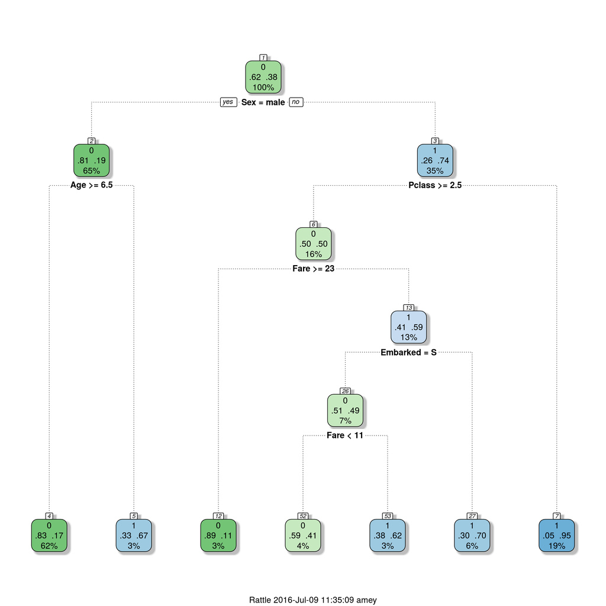

```r
# Create a new train set with the new variable
train_two <- train
train_two$family_size <- train$SibSp + train$Parch + 1

# Create a new decision tree
my_tree_four <- rpart(Survived ~ Pclass + Sex + Age + SibSp + Parch + Fare + Embarked + family_size, data = train_two, method = "class", control = rpart.control(minsplit = 50, cp = 0))

# Visualize new decision tree
fancyRpartPlot(my_tree_four)
```

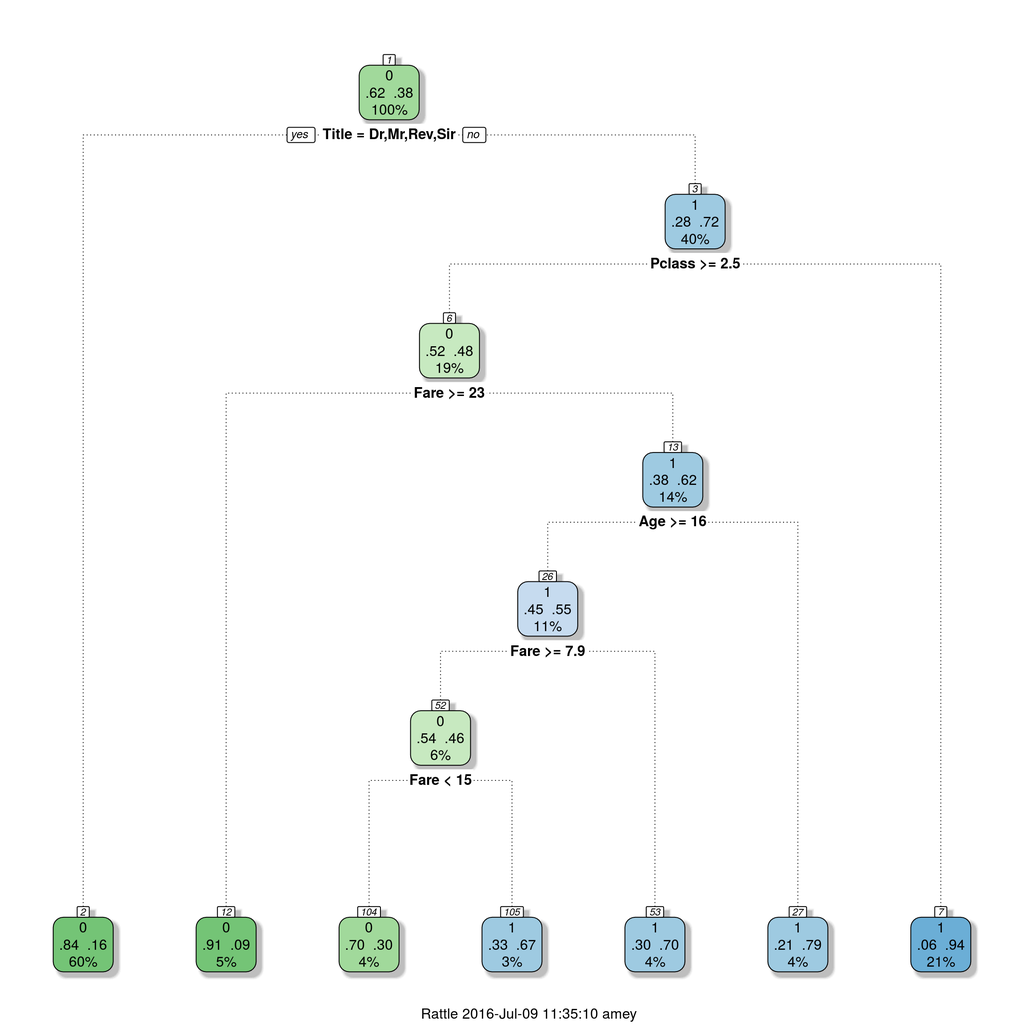

```r
train_new = all_data[1:891,]
train_new = subset(train_new , select =  -c(family_size))
test_new = all_data[892:1309,]
test_new = subset(test_new , select =  -c(family_size))

# Create a new decision tree
my_tree_five <- rpart(Survived ~ Pclass + Sex + Age + SibSp + Parch + Fare + Embarked + Title,
                                     data = train_new, method = 'class')

# Visualize new decision tree
fancyRpartPlot(my_tree_five)
```

```r
# Make prediction using `my_tree_five` and `test_new`
my_prediction <- my_prediction <- predict(my_tree_five, test_new, type = 'class')

# Create a data frame with two columns: PassengerId & Survived. Survived contains predictions
my_solution2 <- data.frame(PassengerId = test_new$PassengerId, Survived = my_prediction)

# Write solution away to a csv file with the name my_solution.csv
write.csv(my_solution2, file = 'my_solution2.csv', row.names = FALSE)

# View my_solution2
my_solution2
```

```
##      PassengerId Survived
## 892          892        0
## 893          893        1
## 894          894        0
## 895          895        0
## 896          896        0
## 897          897        0
## 898          898        1
## 899          899        0
## 900          900        1
## 901          901        0
## 902          902        0
## 903          903        0
## 904          904        1
## 905          905        0
```

[output cut: 404 more lines]

### Random Forest

Random forest technique handles the overfitting problem faced in decision trees. To implement Random Forest all the missing values in the data set should be filled via predicition model.

```r
# All data, both training and test set
str(all_data)
```

```
## 'data.frame':    1309 obs. of  14 variables:
##  $ PassengerId: int  1 2 3 4 5 6 7 8 9 10 ...
##  $ Survived   : int  0 1 1 1 0 0 0 0 1 1 ...
##  $ Pclass     : int  3 1 3 1 3 3 1 3 3 2 ...
##  $ Name       : chr  "Braund, Mr. Owen Harris" "Cumings, Mrs. John Bradley (Florence Briggs Thayer)" "Heikkinen, Miss. Laina" "Futrelle, Mrs. Jacques Heath (Lily May Peel)" ...
##  $ Sex        : Factor w/ 2 levels "female","male": 2 1 1 1 2 2 2 2 1 1 ...
##  $ Age        : num  22 38 26 35 35 NA 54 2 27 14 ...
##  $ SibSp      : int  1 1 0 1 0 0 0 3 0 1 ...
##  $ Parch      : int  0 0 0 0 0 0 0 1 2 0 ...
##  $ Ticket     : Factor w/ 929 levels "110152","110413",..: 524 597 670 50 473 276 86 396 345 133 ...
##  $ Fare       : num  7.25 71.28 7.92 53.1 8.05 ...
##  $ Cabin      : Factor w/ 187 levels "","A10","A14",..: 1 83 1 57 1 1 131 1 1 1 ...
##  $ Embarked   : Factor w/ 4 levels "","C","Q","S": 4 2 4 4 4 3 4 4 4 2 ...
##  $ family_size: num  2 2 1 2 1 1 1 5 3 2 ...
##  $ Title      : Factor w/ 11 levels "Col","Dr","Lady",..: 7 8 5 8 7 7 7 4 8 8 ...
```

```r
# Passenger on row 62 and 830 do not have a value for embarkment.
# Since many passengers embarked at Southampton, we give them the value S.
# Code all embarkment codes as factors.
all_data$Embarked[c(62,830)] = "S"
all_data$Embarked <- factor(all_data$Embarked)

# Passenger on row 1044 has an NA Fare value. Replace it with the median fare value.
all_data$Fare[1044] <- median(all_data$Fare, na.rm=TRUE)

# To fill the missing age value
# Make a prediction of a passengers Age using the other variables and a decision tree model.
#  method="anova" is used since we are predicting a continuous variable.
predicted_age <- rpart(Age ~ Pclass + Sex + SibSp + Parch + Fare + Embarked + Title + family_size,
                       data=all_data[!is.na(all_data$Age),], method="anova")
all_data$Age[is.na(all_data$Age)] <- predict(predicted_age, all_data[is.na(all_data$Age),])

# Split the data back into a train set and a test set
train <- all_data[1:891,]
test <- all_data[892:1309,]

# Set seed for reproducibility
set.seed(111)

# Apply the Random Forest Algorithm
my_forest <- randomForest(as.factor(Survived) ~ Pclass + Sex + Age + SibSp + Parch + Fare + Embarked + Title,
                          data=train, importance=TRUE, ntree=1000)

# Make prediction using the test set
my_prediction <- predict(my_forest, test)

# Create a data frame with two columns: PassengerId & Survived. Survived contains predictions
my_solution3 <- data.frame(PassengerId = test$PassengerId, Survived = my_prediction)

# Write solution away to a csv file with the name my_solution.csv
write.csv(my_solution3, file = "my_solution3.csv", row.names = FALSE)

# View my_solution3
my_solution3
```

```
##      PassengerId Survived
## 892          892        0
## 893          893        0
## 894          894        0
## 895          895        0
## 896          896        1
## 897          897        0
## 898          898        0
## 899          899        0
## 900          900        1
## 901          901        0
## 902          902        0
## 903          903        0
## 904          904        1
## 905          905        0
```

[output cut: 404 more lines]